# INCC

#### IGP12_INCCMG1D12

INCC-M - 1º decêndio --> levantamento de dados feito entre o dia 21 do mês anterior até o dia 20 do mês analisado

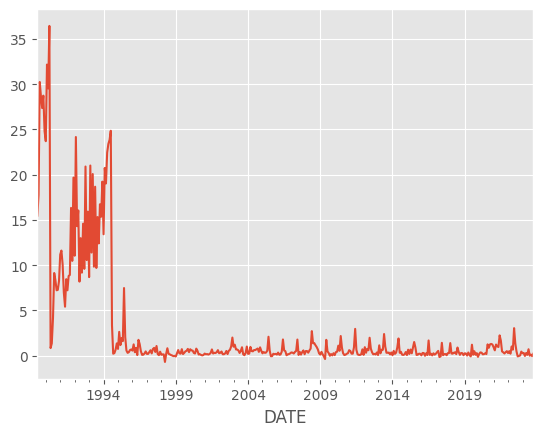

```python
ip.timeseries("IGP12_INCCMG1D12")
IGP12_INCCMG1D12 = ip.timeseries("IGP12_INCCMG1D12")

IGP12_INCCMG1D12.columns

IGP12_INCCMG1D12["VALUE ((% a.m.))"].plot()
```

Utilizando Média Movel Simples para 12 periodos (12 meses)

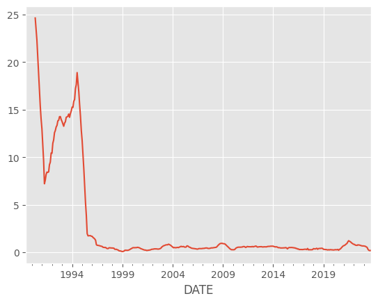

```python
IGP12_INCCMG1D12["VALUE ((% a.m.))"].rolling(12).mean()
#percebe-se os 12 primeiro nulos, pq so dps do mes 12 conseguimos calcular a média móvel

IGP12_INCCMG1D12["VALUE ((% a.m.))"].rolling(12).mean().plot()
```

Sazonalidade

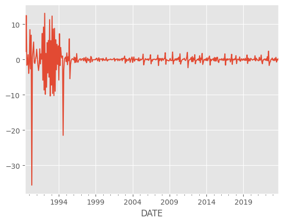

```python
IGP12_INCCMG1D12["VALUE ((% a.m.))"].diff()

IGP12_INCCMG1D12["VALUE ((% a.m.))"].diff().plot()
```

Baixa em 1990 e 1994

Comportamento Sazonal por mês

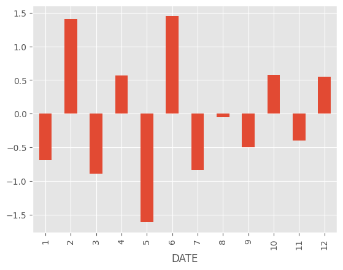

```python
IGP12_INCCMG1D12["VALUE ((% a.m.))"].diff().groupby(IGP12_INCCMG1D12.index.month).mean().plot(kind='bar')
```

Já percebemos altas nos meses pares, com exceção de agosto.

Autocorrelação Total e Parcial

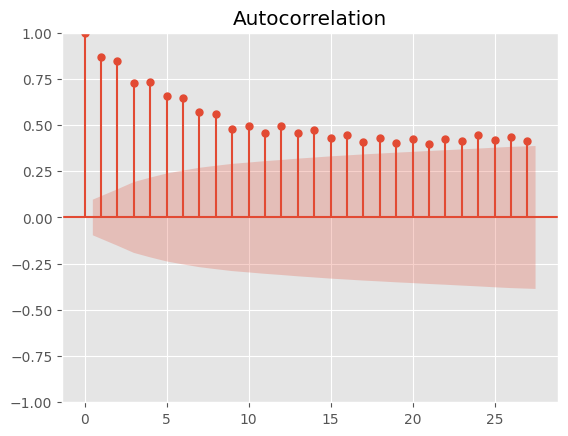

```python
plot_acf(IGP12_INCCMG1D12["VALUE ((% a.m.))"])
plt.show()
```

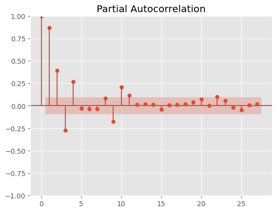

```python
plot_pacf(IGP12_INCCMG1D12["VALUE ((% a.m.))"])
plt.show()
```

Modelo AR(1)

#### IGP12_INCCMG2D12

INCC-M - 2º decêndio --> levantamento de dados feito entre o dia 21 do mês anterior até o dia 20 do mês analisado

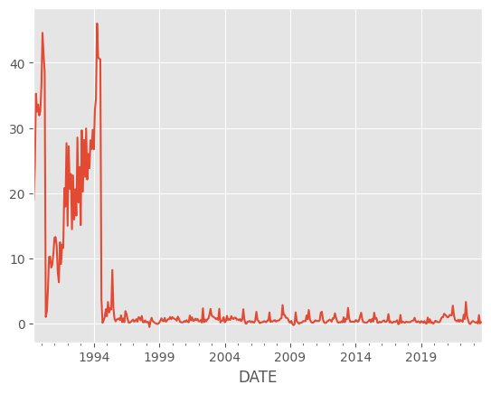

```python
ip.timeseries("IGP12_INCCMG2D12")
IGP12_INCCMG2D12 = ip.timeseries("IGP12_INCCMG2D12")

IGP12_INCCMG2D12.columns

IGP12_INCCMG2D12["VALUE ((% a.m.))"].plot()
```

Utilizando Média Movel Simples para 12 periodos (12 meses)

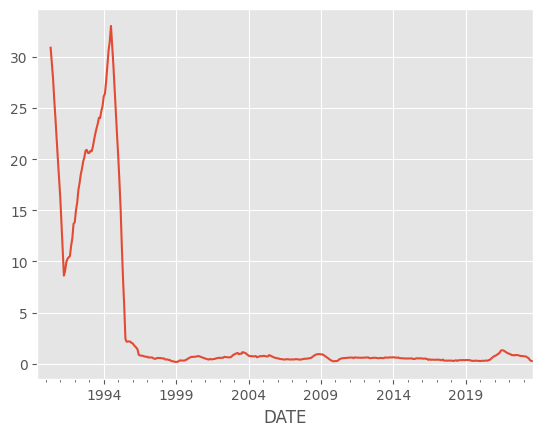

```python
IGP12_INCCMG2D12["VALUE ((% a.m.))"].rolling(12).mean()
#percebe-se os 12 primeiro nulos, pq so dps do mes 12 conseguimos calcular a média móvel

IGP12_INCCMG2D12["VALUE ((% a.m.))"].rolling(12).mean().plot()
```

Sazonalidade

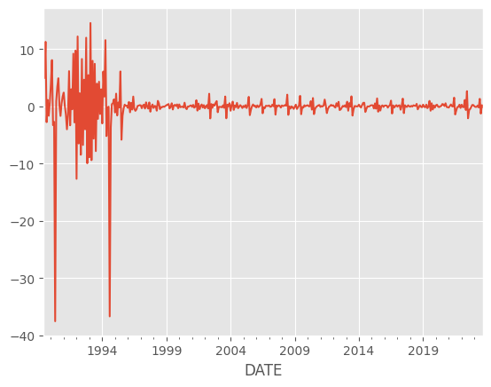

```python
IGP12_INCCMG2D12["VALUE ((% a.m.))"].diff()

IGP12_INCCMG2D12["VALUE ((% a.m.))"].diff().plot()
```

Quedas em 1990 e 1994

Comportamento Sazonal por mês

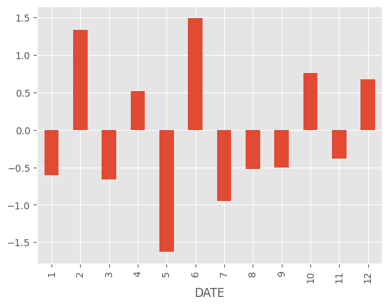

```python
IGP12_INCCMG2D12["VALUE ((% a.m.))"].diff().groupby(IGP12_INCCMG2D12.index.month).mean().plot(kind='bar')
```

Novamente, altas nos meses pares e quedas nos ímpares, com exceção de agosto.

Autocorrelação Total e Parcial

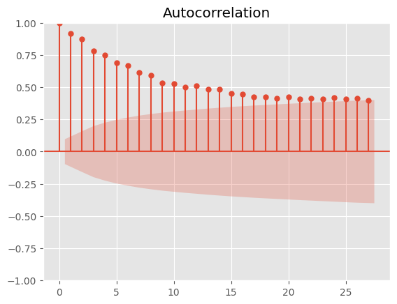

```python
plot_acf(IGP12_INCCMG2D12["VALUE ((% a.m.))"])
plt.show()
```

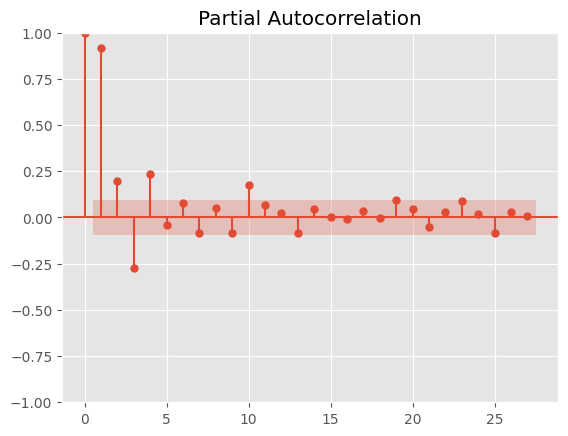

```python
plot_pacf(IGP12_INCCMG2D12["VALUE ((% a.m.))"])
plt.show()
```

Modelo AR(1)